# Data Transformation and Manipulation

Feb 14, 2019

Data transformation manipulation is usually a necessary procedure in the exploratory data analysis, and even during modeling. The reason is that you can rarely get the dataset in a perfect form as you expected.

In this lab, you will learn many useful techniques to transform the data as you wanted, including adding/dropping variables, rename variables, filtering, lagging, reordering, etc.. We use a flight dataset (in pacakge dplyr) for illustration.

## Preparation

Before start, always do

- set the working directory!
- create a new R script (unless you are continuing writing previous code)
- Save the R script.

```r
setwd("/yourfolder")
```

Most functions we are using here are in the package `dplyr`. So we first load package `tidyverse`, which is a package of packages including `dplyr` and `ggplot2`.

```r
library(tidyverse)
```

We will introduce these functions

- `filter()`
- `arrange()`
- `select()`
- `rename()`
- `mutate()`
- `summarise()`

All verbs work similarly:

1. The first argument is a data frame.
2. The subsequent arguments describe what to do with the data frame, using the variable names (without quotes).
3. The result is a new data frame.

### Load data

The dataset we are using here is in a package called `nycflights13`. So you may need to install this package first.

```r
install.packages("nycflights13")
```

```r
library(nycflights13)

# print out first few rows and columns of the flight data
flights
```

```
## # A tibble: 336,776 x 19
##     year month   day dep_time sched_dep_time dep_delay arr_time
##    <int> <int> <int>    <int>          <int>     <dbl>    <int>
##  1  2013     1     1      517            515         2      830
##  2  2013     1     1      533            529         4      850
##  3  2013     1     1      542            540         2      923
##  4  2013     1     1      544            545        -1     1004
##  5  2013     1     1      554            600        -6      812
##  6  2013     1     1      554            558        -4      740
##  7  2013     1     1      555            600        -5      913
##  8  2013     1     1      557            600        -3      709
##  9  2013     1     1      557            600        -3      838
## 10  2013     1     1      558            600        -2      753
## # ... with 336,766 more rows, and 12 more variables: sched_arr_time <int>,
## #   arr_delay <dbl>, carrier <chr>, flight <int>, tailnum <chr>,
## #   origin <chr>, dest <chr>, air_time <dbl>, distance <dbl>, hour <dbl>,
## #   minute <dbl>, time_hour <dttm>
```

This data frame contains all 336,776 flights that departed from New York City in 2013. You can use `?flights` to learn more details about this each variable.

```r
?flights
```

From the preview, you have already seen the dimension of the data and the type of each variable. Another way to look at varaible type is by using `str()`, which is an R basic function.

```r
str(flights)
```

```
## Classes 'tbl_df', 'tbl' and 'data.frame':    336776 obs. of  19 variables:
##  $ year          : int  2013 2013 2013 2013 2013 2013 2013 2013 2013 2013 ...
##  $ month         : int  1 1 1 1 1 1 1 1 1 1 ...
##  $ day           : int  1 1 1 1 1 1 1 1 1 1 ...
##  $ dep_time      : int  517 533 542 544 554 554 555 557 557 558 ...
##  $ sched_dep_time: int  515 529 540 545 600 558 600 600 600 600 ...
##  $ dep_delay     : num  2 4 2 -1 -6 -4 -5 -3 -3 -2 ...
##  $ arr_time      : int  830 850 923 1004 812 740 913 709 838 753 ...
##  $ sched_arr_time: int  819 830 850 1022 837 728 854 723 846 745 ...
##  $ arr_delay     : num  11 20 33 -18 -25 12 19 -14 -8 8 ...
##  $ carrier       : chr  "UA" "UA" "AA" "B6" ...
##  $ flight        : int  1545 1714 1141 725 461 1696 507 5708 79 301 ...
##  $ tailnum       : chr  "N14228" "N24211" "N619AA" "N804JB" ...
##  $ origin        : chr  "EWR" "LGA" "JFK" "JFK" ...
##  $ dest          : chr  "IAH" "IAH" "MIA" "BQN" ...
##  $ air_time      : num  227 227 160 183 116 150 158 53 140 138 ...
##  $ distance      : num  1400 1416 1089 1576 762 ...
##  $ hour          : num  5 5 5 5 6 5 6 6 6 6 ...
##  $ minute        : num  15 29 40 45 0 58 0 0 0 0 ...
##  $ time_hour     : POSIXct, format: "2013-01-01 05:00:00" "2013-01-01 05:00:00" ...
```

#### summary()

It is usually good to use `summary()` function to get a better sense of each variables in your dataset.

```r
summary(flights)
```

```
##       year          month             day           dep_time
##  Min.   :2013   Min.   : 1.000   Min.   : 1.00   Min.   :   1
##  1st Qu.:2013   1st Qu.: 4.000   1st Qu.: 8.00   1st Qu.: 907
##  Median :2013   Median : 7.000   Median :16.00   Median :1401
##  Mean   :2013   Mean   : 6.549   Mean   :15.71   Mean   :1349
##  3rd Qu.:2013   3rd Qu.:10.000   3rd Qu.:23.00   3rd Qu.:1744
##  Max.   :2013   Max.   :12.000   Max.   :31.00   Max.   :2400
##                                                  NA's   :8255
##  sched_dep_time   dep_delay          arr_time    sched_arr_time
##  Min.   : 106   Min.   : -43.00   Min.   :   1   Min.   :   1
##  1st Qu.: 906   1st Qu.:  -5.00   1st Qu.:1104   1st Qu.:1124
##  Median :1359   Median :  -2.00   Median :1535   Median :1556
##  Mean   :1344   Mean   :  12.64   Mean   :1502   Mean   :1536
##  3rd Qu.:1729   3rd Qu.:  11.00   3rd Qu.:1940   3rd Qu.:1945
##  Max.   :2359   Max.   :1301.00   Max.   :2400   Max.   :2359
##                 NA's   :8255      NA's   :8713
##    arr_delay          carrier              flight       tailnum
##  Min.   : -86.000   Length:336776      Min.   :   1   Length:336776
##  1st Qu.: -17.000   Class :character   1st Qu.: 553   Class :character
##  Median :  -5.000   Mode  :character   Median :1496   Mode  :character
##  Mean   :   6.895                      Mean   :1972
##  3rd Qu.:  14.000                      3rd Qu.:3465
##  Max.   :1272.000                      Max.   :8500
##  NA's   :9430
##     origin              dest              air_time        distance
##  Length:336776      Length:336776      Min.   : 20.0   Min.   :  17
##  Class :character   Class :character   1st Qu.: 82.0   1st Qu.: 502
##  Mode  :character   Mode  :character   Median :129.0   Median : 872
##                                        Mean   :150.7   Mean   :1040
##                                        3rd Qu.:192.0   3rd Qu.:1389
##                                        Max.   :695.0   Max.   :4983
##                                        NA's   :9430
##       hour           minute        time_hour
##  Min.   : 1.00   Min.   : 0.00   Min.   :2013-01-01 05:00:00
##  1st Qu.: 9.00   1st Qu.: 8.00   1st Qu.:2013-04-04 13:00:00
##  Median :13.00   Median :29.00   Median :2013-07-03 10:00:00
##  Mean   :13.18   Mean   :26.23   Mean   :2013-07-03 05:22:54
##  3rd Qu.:17.00   3rd Qu.:44.00   3rd Qu.:2013-10-01 07:00:00
##  Max.   :23.00   Max.   :59.00   Max.   :2013-12-31 23:00:00
##
```

This output is very useful for your analysis, but is not in a good format to report. Therefore, do not copy paste it or screenshot for a formal report.

Back to top

## Filtering – `filter()`

### Filtering by conditions

This performs similar to the “data filter” in Excel to filter with certain specifications. For example, we can select all flights on January 1st with:

```r
filter(flights, month == 1, day == 1)
```

```
## # A tibble: 842 x 19
##     year month   day dep_time sched_dep_time dep_delay arr_time
##    <int> <int> <int>    <int>          <int>     <dbl>    <int>
##  1  2013     1     1      517            515         2      830
##  2  2013     1     1      533            529         4      850
##  3  2013     1     1      542            540         2      923
##  4  2013     1     1      544            545        -1     1004
##  5  2013     1     1      554            600        -6      812
##  6  2013     1     1      554            558        -4      740
##  7  2013     1     1      555            600        -5      913
##  8  2013     1     1      557            600        -3      709
##  9  2013     1     1      557            600        -3      838
## 10  2013     1     1      558            600        -2      753
## # ... with 832 more rows, and 12 more variables: sched_arr_time <int>,
## #   arr_delay <dbl>, carrier <chr>, flight <int>, tailnum <chr>,
## #   origin <chr>, dest <chr>, air_time <dbl>, distance <dbl>, hour <dbl>,
## #   minute <dbl>, time_hour <dttm>
```

Now the result is a new dataset, if you don’t assign it with a new name, this new data is not saved anywhere. It is good to save anything you wish to by assigning the object a new name. The new name can be anything you like.

```r
flgiht.Jan1<- filter(flights, month == 1, day == 1)
```

You can also filter with other conditions such as `<`, `>`, `<=`, `>=`, `!=`. For example, you can get all flights with arrival delay greater than 2 hours (120 mins).

```r
delay2<- filter(flights, arr_delay>120)
```

#### “And”, “Or” conditions

If you want to get all flights that departed in November or December, you can use

```r
flight.NovDec<- filter(flights, month == 11 | month == 12)
```

`a | b` is the condition that either a or b. Note that you cannot omit `|` because `a | b` as a whole is one condition. An equivalent operator is `x %in% y`, which means any rows where `x` contains `y`.

```r
flight.NovDec<- filter(flights, month %in% c(11, 12))
```

You can filter data by multiple conditions. For example, if you want all rows where arrival delay is between 2 and 4 hours, you can write the code as

```r
delay_2_4<- filter(flights, arr_delay>120 & arr_delay<240)
```

Here `&` means “and”. Can you omit `&` for this filtering?

### Missing values

Missing value is commonly seen in real data. However, when it comes to filter, missing values are rather tricky. As we saw from the summary results earlier, there are a few variables containing missing value. For example, if we want to filter out all missing values in variable “arr_delay”, how are you going to write the code? It might be straightforward to write it this way:

```r
filter(flights, arr_delay!=NA)
```

```
## # A tibble: 0 x 19
## # ... with 19 variables: year <int>, month <int>, day <int>,
## #   dep_time <int>, sched_dep_time <int>, dep_delay <dbl>, arr_time <int>,
## #   sched_arr_time <int>, arr_delay <dbl>, carrier <chr>, flight <int>,
## #   tailnum <chr>, origin <chr>, dest <chr>, air_time <dbl>,
## #   distance <dbl>, hour <dbl>, minute <dbl>, time_hour <dttm>
```

Obviously, the result is not right. Let’s run a very simple example to see why it does not work.

```r
a<- c(1, 2, 3, NA, NA)
a!=NA
```

```
## [1] NA NA NA NA NA
```

R would not work when you directly compare values with “NA”. Instead, there is a specific function `is.na()` to handle this. This function checks every single value and returns TRUE if it sees NA, and FALSE if it doesn’t.

```r
is.na(a)
```

```
## [1] FALSE FALSE FALSE  TRUE  TRUE
```

Now you can use this function to filter out all missing values in “arr_delay” in our dataset.

```r
filter(flights, is.na(arr_delay)==FALSE)
```

```
## # A tibble: 327,346 x 19
##     year month   day dep_time sched_dep_time dep_delay arr_time
##    <int> <int> <int>    <int>          <int>     <dbl>    <int>
##  1  2013     1     1      517            515         2      830
##  2  2013     1     1      533            529         4      850
##  3  2013     1     1      542            540         2      923
##  4  2013     1     1      544            545        -1     1004
##  5  2013     1     1      554            600        -6      812
##  6  2013     1     1      554            558        -4      740
##  7  2013     1     1      555            600        -5      913
##  8  2013     1     1      557            600        -3      709
##  9  2013     1     1      557            600        -3      838
## 10  2013     1     1      558            600        -2      753
## # ... with 327,336 more rows, and 12 more variables: sched_arr_time <int>,
## #   arr_delay <dbl>, carrier <chr>, flight <int>, tailnum <chr>,
## #   origin <chr>, dest <chr>, air_time <dbl>, distance <dbl>, hour <dbl>,
## #   minute <dbl>, time_hour <dttm>
```

There are multiple columns containing missing values, how could we filter out all of them without spelling all conditions.

```r
flight.noNA<- na.omit(flights)
sum(is.na(flight.noNA))
```

```
## [1] 0
```

### Exercise

1. Find all flights that
   - 1. Had an arrival delay of two or more hours
   - 2. Flew to Houston (IAH or HOU)
   - 3. Were operated by United, American, or Delta
   - 4. Departed in summer (July, August, and September)
   - 5. Arrived more than two hours late, but didn’t leave late
   - 6. Were delayed by at least an hour, but made up over 30 minutes in flight
   - 7. Departed between midnight and 6am (inclusive)
2. How many flights have a missing dep_time? What other variables are missing? What might these rows represent?

Back to top

## Arrange rows – `arrange()`

#### ascending order

The function `arrange()` performs similar as sorting in Excel. You can sort by multiple columns at the same time. For example, we can sort the flight dataset by “year”, “month”, “day”, and “arr_delay”.

```r
arrange(flights, year, month, day, arr_delay)
```

```
## # A tibble: 336,776 x 19
##     year month   day dep_time sched_dep_time dep_delay arr_time
##    <int> <int> <int>    <int>          <int>     <dbl>    <int>
##  1  2013     1     1     1904           1905        -1     2139
##  2  2013     1     1     1859           1900        -1     2151
##  3  2013     1     1      820            820         0     1249
##  4  2013     1     1     1627           1630        -3     1940
##  5  2013     1     1      840            845        -5     1311
##  6  2013     1     1     1153           1200        -7     1450
##  7  2013     1     1     1245           1249        -4     1722
##  8  2013     1     1     1610           1615        -5     1913
##  9  2013     1     1     2030           2045       -15     2150
## 10  2013     1     1     1641           1650        -9     1746
## # ... with 336,766 more rows, and 12 more variables: sched_arr_time <int>,
## #   arr_delay <dbl>, carrier <chr>, flight <int>, tailnum <chr>,
## #   origin <chr>, dest <chr>, air_time <dbl>, distance <dbl>, hour <dbl>,
## #   minute <dbl>, time_hour <dttm>
```

Most time, you can simply over write your original data if you are doing sorting, because you are not creating any new dataset, and the only thing changed is the row orders.

#### descending order

Apply function `desc()` to the variable you want to sort will result in a descending order sort.

```r
arrange(flights, year, month, day, desc(arr_delay))
```

```
## # A tibble: 336,776 x 19
##     year month   day dep_time sched_dep_time dep_delay arr_time
##    <int> <int> <int>    <int>          <int>     <dbl>    <int>
##  1  2013     1     1      848           1835       853     1001
##  2  2013     1     1     2343           1724       379      314
##  3  2013     1     1     1815           1325       290     2120
##  4  2013     1     1     1842           1422       260     1958
##  5  2013     1     1     2115           1700       255     2330
##  6  2013     1     1     2205           1720       285       46
##  7  2013     1     1     2006           1630       216     2230
##  8  2013     1     1     2312           2000       192       21
##  9  2013     1     1     1942           1705       157     2124
## 10  2013     1     1     1938           1703       155     2109
## # ... with 336,766 more rows, and 12 more variables: sched_arr_time <int>,
## #   arr_delay <dbl>, carrier <chr>, flight <int>, tailnum <chr>,
## #   origin <chr>, dest <chr>, air_time <dbl>, distance <dbl>, hour <dbl>,
## #   minute <dbl>, time_hour <dttm>
```

#### Missing values are always sorted at the end.

Back to top

## Select columns – `select()`

### Keep or drop colums

You may use function `select()` to subset data (drop unnecessary variables). An equivalent approachi is by using `[ , ]` following the dataset.

Using similar syntex, you can specify every single variable you want to keep.

```r
select(flights, year, month, day, flight)
```

```
## # A tibble: 336,776 x 4
##     year month   day flight
##    <int> <int> <int>  <int>
##  1  2013     1     1   1545
##  2  2013     1     1   1714
##  3  2013     1     1   1141
##  4  2013     1     1    725
##  5  2013     1     1    461
##  6  2013     1     1   1696
##  7  2013     1     1    507
##  8  2013     1     1   5708
##  9  2013     1     1     79
## 10  2013     1     1    301
## # ... with 336,766 more rows
```

You can also use `:` to select all variable between two (inclusive).

```r
select(flights, year:day, flight:dest)
```

```
## # A tibble: 336,776 x 7
##     year month   day flight tailnum origin  dest
##    <int> <int> <int>  <int>   <chr>  <chr> <chr>
##  1  2013     1     1   1545  N14228    EWR   IAH
##  2  2013     1     1   1714  N24211    LGA   IAH
##  3  2013     1     1   1141  N619AA    JFK   MIA
##  4  2013     1     1    725  N804JB    JFK   BQN
##  5  2013     1     1    461  N668DN    LGA   ATL
##  6  2013     1     1   1696  N39463    EWR   ORD
##  7  2013     1     1    507  N516JB    EWR   FLL
##  8  2013     1     1   5708  N829AS    LGA   IAD
##  9  2013     1     1     79  N593JB    JFK   MCO
## 10  2013     1     1    301  N3ALAA    LGA   ORD
## # ... with 336,766 more rows
```

You can use minus sign to drop variables.

```r
select(flights, -year, -(flight:dest))
```

```
## # A tibble: 336,776 x 14
##    month   day dep_time sched_dep_time dep_delay arr_time sched_arr_time
##    <int> <int>    <int>          <int>     <dbl>    <int>          <int>
##  1     1     1      517            515         2      830            819
##  2     1     1      533            529         4      850            830
##  3     1     1      542            540         2      923            850
##  4     1     1      544            545        -1     1004           1022
##  5     1     1      554            600        -6      812            837
##  6     1     1      554            558        -4      740            728
##  7     1     1      555            600        -5      913            854
##  8     1     1      557            600        -3      709            723
##  9     1     1      557            600        -3      838            846
## 10     1     1      558            600        -2      753            745
## # ... with 336,766 more rows, and 7 more variables: arr_delay <dbl>,
## #   carrier <chr>, air_time <dbl>, distance <dbl>, hour <dbl>,
## #   minute <dbl>, time_hour <dttm>
```

There are a number of helper functions you can use within select():

- `starts_with("abc")`: matches names that begin with “abc”.
- `ends_with("xyz")`: matches names that end with “xyz”.
- `contains("ijk")`: matches names that contain “ijk”.
- `num_range("x", 1:3)`: matches x1, x2 and x3.

### Rearrange columns

With a helper funcion `everything()`, you can also use `select()` to rearrange the column orders. For example, if you want to bring variable “time_hour” to the first column, you can write

```r
select(flights, time_hour, everything())
```

```
## # A tibble: 336,776 x 19
##              time_hour  year month   day dep_time sched_dep_time dep_delay
##                 <dttm> <int> <int> <int>    <int>          <int>     <dbl>
##  1 2013-01-01 05:00:00  2013     1     1      517            515         2
##  2 2013-01-01 05:00:00  2013     1     1      533            529         4
##  3 2013-01-01 05:00:00  2013     1     1      542            540         2
##  4 2013-01-01 05:00:00  2013     1     1      544            545        -1
##  5 2013-01-01 06:00:00  2013     1     1      554            600        -6
##  6 2013-01-01 05:00:00  2013     1     1      554            558        -4
##  7 2013-01-01 06:00:00  2013     1     1      555            600        -5
##  8 2013-01-01 06:00:00  2013     1     1      557            600        -3
##  9 2013-01-01 06:00:00  2013     1     1      557            600        -3
## 10 2013-01-01 06:00:00  2013     1     1      558            600        -2
## # ... with 336,766 more rows, and 12 more variables: arr_time <int>,
## #   sched_arr_time <int>, arr_delay <dbl>, carrier <chr>, flight <int>,
## #   tailnum <chr>, origin <chr>, dest <chr>, air_time <dbl>,
## #   distance <dbl>, hour <dbl>, minute <dbl>
```

### Rename variable – `rename()`

This function simply renames variable.

```r
rename(flights, tail_num=tailnum)
```

```
## # A tibble: 336,776 x 19
##     year month   day dep_time sched_dep_time dep_delay arr_time
##    <int> <int> <int>    <int>          <int>     <dbl>    <int>
##  1  2013     1     1      517            515         2      830
##  2  2013     1     1      533            529         4      850
##  3  2013     1     1      542            540         2      923
##  4  2013     1     1      544            545        -1     1004
##  5  2013     1     1      554            600        -6      812
##  6  2013     1     1      554            558        -4      740
##  7  2013     1     1      555            600        -5      913
##  8  2013     1     1      557            600        -3      709
##  9  2013     1     1      557            600        -3      838
## 10  2013     1     1      558            600        -2      753
## # ... with 336,766 more rows, and 12 more variables: sched_arr_time <int>,
## #   arr_delay <dbl>, carrier <chr>, flight <int>, tail_num <chr>,
## #   origin <chr>, dest <chr>, air_time <dbl>, distance <dbl>, hour <dbl>,
## #   minute <dbl>, time_hour <dttm>
```

Back to top

## Add new variables – `mutate()`

Often times it is necessary to add new columns to your data. These new columns could be calculations based on existing variables. You can use `mutate()` function and perform most calculations inside this function.

```r
# let's first drop some variables for convenience
flights_sml <- select(flights,
  year:day,
  ends_with("delay"),
  distance,
  air_time
)
# adding new variables "gain" and "speed"
mutate(flights,
  gain = dep_delay - arr_delay,
  speed = distance / air_time * 60
)
```

```
## # A tibble: 336,776 x 21
##     year month   day dep_time sched_dep_time dep_delay arr_time
##    <int> <int> <int>    <int>          <int>     <dbl>    <int>
##  1  2013     1     1      517            515         2      830
##  2  2013     1     1      533            529         4      850
##  3  2013     1     1      542            540         2      923
##  4  2013     1     1      544            545        -1     1004
##  5  2013     1     1      554            600        -6      812
##  6  2013     1     1      554            558        -4      740
##  7  2013     1     1      555            600        -5      913
##  8  2013     1     1      557            600        -3      709
##  9  2013     1     1      557            600        -3      838
## 10  2013     1     1      558            600        -2      753
## # ... with 336,766 more rows, and 14 more variables: sched_arr_time <int>,
## #   arr_delay <dbl>, carrier <chr>, flight <int>, tailnum <chr>,
## #   origin <chr>, dest <chr>, air_time <dbl>, distance <dbl>, hour <dbl>,
## #   minute <dbl>, time_hour <dttm>, gain <dbl>, speed <dbl>
```

You can also use the newly created columns in another calculation.

```r
mutate(flights_sml,
  gain = dep_delay - arr_delay,
  hours = air_time / 60,
  gain_per_hour = gain / hours
)
```

```
## # A tibble: 336,776 x 10
##     year month   day dep_delay arr_delay distance air_time  gain     hours
##    <int> <int> <int>     <dbl>     <dbl>    <dbl>    <dbl> <dbl>     <dbl>
##  1  2013     1     1         2        11     1400      227    -9 3.7833333
##  2  2013     1     1         4        20     1416      227   -16 3.7833333
##  3  2013     1     1         2        33     1089      160   -31 2.6666667
##  4  2013     1     1        -1       -18     1576      183    17 3.0500000
##  5  2013     1     1        -6       -25      762      116    19 1.9333333
##  6  2013     1     1        -4        12      719      150   -16 2.5000000
##  7  2013     1     1        -5        19     1065      158   -24 2.6333333
##  8  2013     1     1        -3       -14      229       53    11 0.8833333
##  9  2013     1     1        -3        -8      944      140     5 2.3333333
## 10  2013     1     1        -2         8      733      138   -10 2.3000000
## # ... with 336,766 more rows, and 1 more variables: gain_per_hour <dbl>
```

You can use `transmute()` to only keep the newly created variables. It performs as a combination of `mutate()` and `select()`.

If you recall integer and modulo division, sometimes they are useful.

```r
transmute(flights,
  dep_time,
  hour = dep_time %/% 100,
  minute = dep_time %% 100
)
```

```
## # A tibble: 336,776 x 3
##    dep_time  hour minute
##       <int> <dbl>  <dbl>
##  1      517     5     17
##  2      533     5     33
##  3      542     5     42
##  4      544     5     44
##  5      554     5     54
##  6      554     5     54
##  7      555     5     55
##  8      557     5     57
##  9      557     5     57
## 10      558     5     58
## # ... with 336,766 more rows
```

Back to top

## Grouped summaries – `summarise()` and `group_by()`

The function `summarise()` collapses data with some summary statistics. Unlike R basic function`summary()`, which produces only some certain summary statistics, `summarise()` is much more flexible, and is doing whatever you ask. It is worth to note that the results produced by `summarise()` is again a “tibble” (similar to data frame). For example, to get the mean of “dep_delay”, we can write

```r
summarise(flights, delay = mean(dep_delay, na.rm = TRUE))
```

```
## # A tibble: 1 x 1
##      delay
##      <dbl>
## 1 12.63907
```

This is still a tibble. But if you use `mean(flights$dep_deplay, na.rm=TRUE)`, the result is simply a number.

### Pair `group_by()` with `summarise()`

It is extremely helpful if you pair `group_by()` with `summarise()`. For example, you can obtain the average of “dep_delay” in every single day by writing

```r
by_day <- group_by(flights, year, month, day)
summarise(by_day, delay = mean(dep_delay, na.rm = TRUE))
```

```
## # A tibble: 365 x 4
## # Groups:   year, month [?]
##     year month   day     delay
##    <int> <int> <int>     <dbl>
##  1  2013     1     1 11.548926
##  2  2013     1     2 13.858824
##  3  2013     1     3 10.987832
##  4  2013     1     4  8.951595
##  5  2013     1     5  5.732218
##  6  2013     1     6  7.148014
##  7  2013     1     7  5.417204
##  8  2013     1     8  2.553073
##  9  2013     1     9  2.276477
## 10  2013     1    10  2.844995
## # ... with 355 more rows
```

The function `group_by()` itself does not change the look of data (you can simply run `by_day` to check), but it has added an underlying group structure to the original data, so that `summarise()` will recognize it.

You can simply get the count by using function `n()` in `summarise()`. For example, to know how many flights have departed from each airport, you can write

```r
by_orig <- group_by(flights, origin)
summarise(by_orig, num.flight = n())
```

```
## # A tibble: 3 x 2
##   origin num.flight
##    <chr>      <int>
## 1    EWR     120835
## 2    JFK     111279
## 3    LGA     104662
```

#### Exercise:

1. What is average of departure delay (“dep_delay”) by each orgin airport and by each carrier?
2. Obtain the number of departure flights by each origin airport and each carrier?
3. Check the help document for `aggregate()`. Try to get obtain the same results.
4. Based on (1), how would you sort “dep_delay” from high to low for each airport?

### Combining multiple operations using pipe – `%>%`

Recall the “+” when we were doing `ggplot`. It basically means adding multiple layers step by step. Similarly, when you are manipulating data, you can use pipe – `%>%` to do things step by step. Therefore you can interpret `%>%` as “then”.

For example, we want to explore the relationship between the distance and average arrival delay for each location, then we can first use `summarise()` and `group_by()` to aggregate the data as below.

```r
by_dest <- group_by(flights, dest)
delay <- summarise(by_dest,
  count = n(),  # creates a column of count (how many flights for each destination)
  dist = mean(distance, na.rm = TRUE), # creates the average distance
  delay = mean(arr_delay, na.rm = TRUE) # creates the average delay time
)
delay <- filter(delay, count > 20)
```

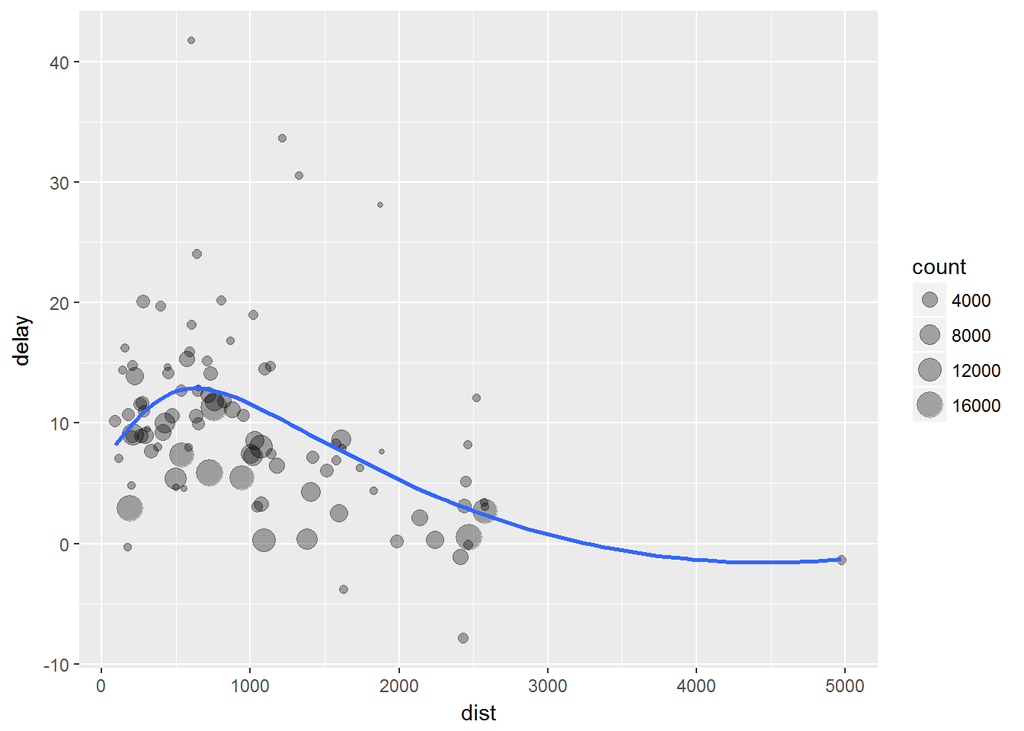

```r
ggplot(data = delay, mapping = aes(x = dist, y = delay)) +
  geom_point(aes(size = count), alpha = 1/3) +
  geom_smooth(se = FALSE)
```

To get the data delay, we did three steps: set group structure, summarise, filter. Now you can complete them with pipe.

```r
delays <- flights %>%
  group_by(dest) %>%
  summarise(
    count = n(),
    dist = mean(distance, na.rm = TRUE),
    delay = mean(arr_delay, na.rm = TRUE)
  ) %>%
  filter(count > 20)
```

One of the advantages of using `%>%` is the readability. Sequentially, the code is very easy to understand.

### Other useful summary functions

- Measure of location: `mean(x)`, `min(x)`, `max(x)`, `median(x)`, `quantile(x, prob=0.8)`.
- Measure of spread: `sd(x)`, `var(x)`, `mad()` (median absolute deviation).
- Measure of position: `first(x)`, `last(x)`, `nth(x, 2)`
- Counts: `n()`, `sum(!is.na(x))` (count for nonmissing values), `n_distinct(x)` (count for unique values), `sum(x>10)` (count by conditions).

### Grouped filter

Suppose that you wanted to filter the data with all destination airport having more than 1000 arrivial flights in the whole year. Intuitively, you would first find those airport, and then do a filtering. Now you complete it in one step using `%>%`.

```r
popular_dests <- flights %>%
  group_by(dest) %>%
  filter(n() > 1000)
popular_dests
```

```
## # A tibble: 320,366 x 19
## # Groups:   dest [58]
##     year month   day dep_time sched_dep_time dep_delay arr_time
##    <int> <int> <int>    <int>          <int>     <dbl>    <int>
##  1  2013     1     1      517            515         2      830
##  2  2013     1     1      533            529         4      850
##  3  2013     1     1      542            540         2      923
##  4  2013     1     1      554            600        -6      812
##  5  2013     1     1      554            558        -4      740
##  6  2013     1     1      555            600        -5      913
##  7  2013     1     1      557            600        -3      709
##  8  2013     1     1      557            600        -3      838
##  9  2013     1     1      558            600        -2      753
## 10  2013     1     1      558            600        -2      849
## # ... with 320,356 more rows, and 12 more variables: sched_arr_time <int>,
## #   arr_delay <dbl>, carrier <chr>, flight <int>, tailnum <chr>,
## #   origin <chr>, dest <chr>, air_time <dbl>, distance <dbl>, hour <dbl>,
## #   minute <dbl>, time_hour <dttm>
```

#### Exercise

1. Suppose that you are looking into the arrival delays, and you are interested in the flights with following delay scenarios:
   - 1. A flight is 15 minutes early 50% of the time, and 15 minutes late 50% of the time.
   - 2. A flight is always 10 minutes late.
   - 3. A flight is 30 minutes early 50% of the time, and 30 minutes late 50% of the time.
   - 4. 99% of the time a flight is on time. 1% of the time it’s 2 hours late. Use what you just learned to obtain data for each of above scenarios.
2. Look at the number of cancelled flights per day (“dep_delay” is missing). Is there a pattern? Is the proportion of cancelled flights related to the average delay?
3. For each destination, compute the total minutes of delay. For each flight, compute the proportion of the total delay for its destination.
4. Which plane (tailnum) has the worst on-time record?
5. For each plane, count the number of flights before the first delay of greater than 1 hour.

#### Exercise

- Download the customer data [here](http://homepages.uc.edu/~lis6/Teaching/DM2017Fall/Data/CustomerData.csv), and read into R.
- How many rows and columns of the dataset?
- Print first few rows the dataset.
- Obtain the summary statistics (Min, Median, Max, Mean and Std.) for *Age*, *EducationYears*, *HHIncome*, and *CreditDebt*.
- Obtain the mean of *HHIncome* by *MaritalStatus*
- Obtain a pivot table of *LoanDefault* vs. *JobCategory*. Which Job Category has the highest and lowerst loan default rate?

Back to top